# Propensity Scores

```r
library(tidyverse)
library(broom)
library(cidata)
library(ggdag)
```

Using the National Health and Nutrition Examination Survey Data (`nhefs_complete`), we are interested in the relationship between the **exposure**, `qsmk`: whether the participant quit smoking, and the **outcome**, `wt82_71`: their weight change in kilograms.

Below is a proposed DAG of the relationship between 4 confounders: `sex`, `age`, `smokeyrs` and `wt71` and the exposure and outcome.

*Knit this document to see the DAG or refer to the slides*.

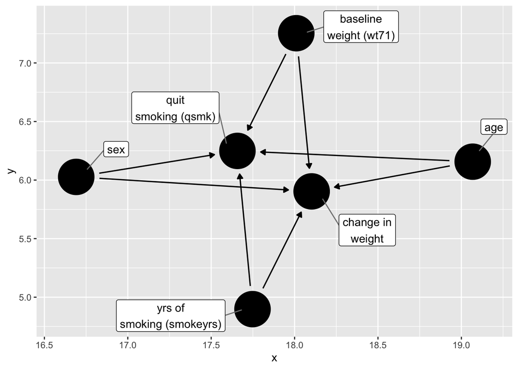

```r
set.seed(1234)
# set up DAG
smk_wt_dag <- dagify(
  # specify causes of quitting smoking and weight gain:
  qsmk ~ sex + age + smokeyrs + wt71,
  wt82_71 ~ sex + age + smokeyrs + wt71,
  # specify causal question:
  exposure = "qsmk",
  outcome = "wt82_71",
  # set up labels:
  # here, I'll use the same variable names as the data set, but I'll label them
  # with clearer names
  labels = c(
    # causal question
    "qsmk" = "quit\nsmoking (qsmk)",
    "wt82_71" = "change in\nweight",

    # demographics
    "age" = "age",
    "sex" = "sex",

    # health
    "wt71" = "baseline\nweight (wt71)",

    # smoking history
    "smokeyrs" = "yrs of\nsmoking (smokeyrs)"
  )
) %>%
  tidy_dagitty()

smk_wt_dag %>%
  ggdag(text = FALSE, use_labels = "label")
```

## Your Turn

*After updating the code chunks below, change `eval = TRUE` before knitting.*

Fit a propensity score model for `qsmk` using the above proposed confounders.

```r
propensity_model <- glm(
  qsmk ~ sex + wt71 + age + smokeyrs,
  data = nhefs_complete,
  family = "binomial"
)
```

Add the propensity scores to the `nhefs_complete` data set, call this new dataset `df`.

```r
df <- propensity_model %>%
  augment(type.predict = "response", data = nhefs_complete)
```

Note: the propensity score will be saved inside df as variable “.fitted”, among others things.

```r
head(unlist(df$.fitted))
```

```
## [1] 0.2493405 0.2070188 0.3221484 0.3398821 0.3059053 0.2591109
```

Stretch Goal 1:

Examine two histograms of the propensity scores, one for those that quit smoking (`qsmk == 1`) and one for those that did not (`qsmk == 0`). How do these compare?

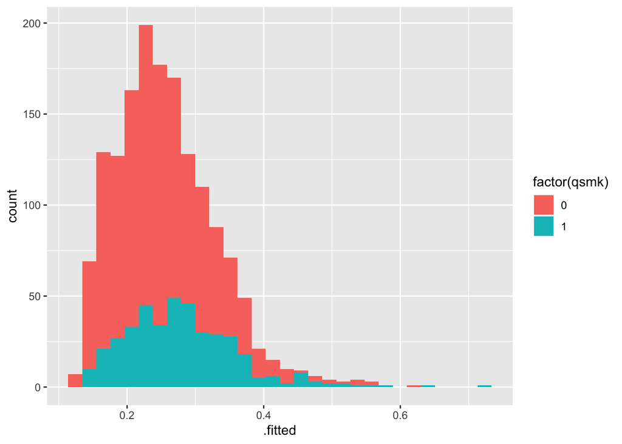

```r
# alternative 1
# par(mfrow=c(1,2))
# hist(unlist(df[df$qsmk==0, ".fitted"]), ylim = c(0,400), xlim = c(0,1))
# hist(unlist(df[df$qsmk==1, ".fitted"]), ylim = c(0,400), xlim = c(0,1))
# alternative 2
ggplot(df, aes(.fitted, group=qsmk, fill=factor(qsmk))) + geom_histogram()
```